# Risk Factor Analysis

## Outcome Variable

**Outcome Variable:** haz

## Predictor Variables

**Intervention Variable:** anywast06

**Adjustment Set:**

- arm
- sex
- brthmon
- W_mage
- meducyrs
- hhwealth_quart
- W_nrooms
- month
- impfloor
- delta_W_mage
- delta_meducyrs
- delta_hhwealth_quart
- delta_W_nrooms
- delta_month
- delta_impfloor

## Stratifying Variables

The analysis was stratified on these variable(s):

- agecat
- studyid
- country

## Data Summary

| agecat | studyid | country | anywast06 | n_cell | n |
| --- | --- | --- | --- | --- | --- |
| Birth | ki0047075b-MAL-ED | BANGLADESH | 0 | 177 | 229 |
| Birth | ki0047075b-MAL-ED | BANGLADESH | 1 | 52 | 229 |
| Birth | ki0047075b-MAL-ED | BRAZIL | 0 | 62 | 65 |
| Birth | ki0047075b-MAL-ED | BRAZIL | 1 | 3 | 65 |
| Birth | ki0047075b-MAL-ED | INDIA | 0 | 33 | 47 |
| Birth | ki0047075b-MAL-ED | INDIA | 1 | 14 | 47 |
| Birth | ki0047075b-MAL-ED | NEPAL | 0 | 23 | 27 |
| Birth | ki0047075b-MAL-ED | NEPAL | 1 | 4 | 27 |
| Birth | ki0047075b-MAL-ED | PERU | 0 | 223 | 233 |
| Birth | ki0047075b-MAL-ED | PERU | 1 | 10 | 233 |
| Birth | ki0047075b-MAL-ED | SOUTH AFRICA | 0 | 102 | 122 |
| Birth | ki0047075b-MAL-ED | SOUTH AFRICA | 1 | 20 | 122 |
| Birth | ki0047075b-MAL-ED | TANZANIA, UNITED REPUBLIC OF | 0 | 119 | 124 |
| Birth | ki0047075b-MAL-ED | TANZANIA, UNITED REPUBLIC OF | 1 | 5 | 124 |
| Birth | ki1000108-CMC-V-BCS-2002 | INDIA | 0 | 37 | 92 |
| Birth | ki1000108-CMC-V-BCS-2002 | INDIA | 1 | 55 | 92 |
| Birth | ki1000108-IRC | INDIA | 0 | 164 | 388 |
| Birth | ki1000108-IRC | INDIA | 1 | 224 | 388 |
| Birth | ki1000109-EE | PAKISTAN | 0 | 156 | 240 |
| Birth | ki1000109-EE | PAKISTAN | 1 | 84 | 240 |
| Birth | ki1000109-ResPak | PAKISTAN | 0 | 28 | 42 |
| Birth | ki1000109-ResPak | PAKISTAN | 1 | 14 | 42 |
| Birth | ki1017093b-PROVIDE | BANGLADESH | 0 | 396 | 539 |
| Birth | ki1017093b-PROVIDE | BANGLADESH | 1 | 143 | 539 |
| Birth | ki1101329-Keneba | GAMBIA | 0 | 9 | 13 |
| Birth | ki1101329-Keneba | GAMBIA | 1 | 4 | 13 |
| Birth | ki1113344-GMS-Nepal | NEPAL | 0 | 422 | 684 |
| Birth | ki1113344-GMS-Nepal | NEPAL | 1 | 262 | 684 |
| Birth | ki1114097-CMIN | BANGLADESH | 0 | 15 | 20 |
| Birth | ki1114097-CMIN | BANGLADESH | 1 | 5 | 20 |

[output cut: 70 more lines]

The following strata were considered:

- agecat: 24 months, studyid: ki0047075b-MAL-ED, country: BANGLADESH
- agecat: 24 months, studyid: ki0047075b-MAL-ED, country: BRAZIL
- agecat: 24 months, studyid: ki0047075b-MAL-ED, country: INDIA
- agecat: 24 months, studyid: ki0047075b-MAL-ED, country: NEPAL
- agecat: 24 months, studyid: ki0047075b-MAL-ED, country: PERU
- agecat: 24 months, studyid: ki0047075b-MAL-ED, country: SOUTH AFRICA
- agecat: 24 months, studyid: ki0047075b-MAL-ED, country: TANZANIA, UNITED REPUBLIC OF
- agecat: 24 months, studyid: ki1000108-CMC-V-BCS-2002, country: INDIA
- agecat: 24 months, studyid: ki1000108-IRC, country: INDIA
- agecat: 24 months, studyid: ki1000109-EE, country: PAKISTAN
- agecat: 24 months, studyid: ki1017093b-PROVIDE, country: BANGLADESH
- agecat: 24 months, studyid: ki1066203-TanzaniaChild2, country: TANZANIA, UNITED REPUBLIC OF
- agecat: 24 months, studyid: ki1101329-Keneba, country: GAMBIA
- agecat: 24 months, studyid: ki1113344-GMS-Nepal, country: NEPAL
- agecat: 24 months, studyid: ki1114097-CMIN, country: BANGLADESH
- agecat: 24 months, studyid: ki1114097-CONTENT, country: PERU
- agecat: 6 months, studyid: ki0047075b-MAL-ED, country: BANGLADESH
- agecat: 6 months, studyid: ki0047075b-MAL-ED, country: BRAZIL
- agecat: 6 months, studyid: ki0047075b-MAL-ED, country: INDIA
- agecat: 6 months, studyid: ki0047075b-MAL-ED, country: NEPAL
- agecat: 6 months, studyid: ki0047075b-MAL-ED, country: PERU
- agecat: 6 months, studyid: ki0047075b-MAL-ED, country: SOUTH AFRICA
- agecat: 6 months, studyid: ki0047075b-MAL-ED, country: TANZANIA, UNITED REPUBLIC OF
- agecat: 6 months, studyid: ki1000108-CMC-V-BCS-2002, country: INDIA
- agecat: 6 months, studyid: ki1000108-IRC, country: INDIA
- agecat: 6 months, studyid: ki1000109-EE, country: PAKISTAN
- agecat: 6 months, studyid: ki1000109-ResPak, country: PAKISTAN
- agecat: 6 months, studyid: ki1017093b-PROVIDE, country: BANGLADESH
- agecat: 6 months, studyid: ki1066203-TanzaniaChild2, country: TANZANIA, UNITED REPUBLIC OF
- agecat: 6 months, studyid: ki1101329-Keneba, country: GAMBIA
- agecat: 6 months, studyid: ki1112895-Guatemala BSC, country: GUATEMALA
- agecat: 6 months, studyid: ki1113344-GMS-Nepal, country: NEPAL
- agecat: 6 months, studyid: ki1114097-CMIN, country: BANGLADESH
- agecat: 6 months, studyid: ki1114097-CONTENT, country: PERU
- agecat: Birth, studyid: ki0047075b-MAL-ED, country: BANGLADESH
- agecat: Birth, studyid: ki0047075b-MAL-ED, country: BRAZIL
- agecat: Birth, studyid: ki0047075b-MAL-ED, country: INDIA
- agecat: Birth, studyid: ki0047075b-MAL-ED, country: NEPAL
- agecat: Birth, studyid: ki0047075b-MAL-ED, country: PERU
- agecat: Birth, studyid: ki0047075b-MAL-ED, country: SOUTH AFRICA
- agecat: Birth, studyid: ki0047075b-MAL-ED, country: TANZANIA, UNITED REPUBLIC OF
- agecat: Birth, studyid: ki1000108-CMC-V-BCS-2002, country: INDIA
- agecat: Birth, studyid: ki1000108-IRC, country: INDIA
- agecat: Birth, studyid: ki1000109-EE, country: PAKISTAN
- agecat: Birth, studyid: ki1000109-ResPak, country: PAKISTAN
- agecat: Birth, studyid: ki1017093b-PROVIDE, country: BANGLADESH
- agecat: Birth, studyid: ki1101329-Keneba, country: GAMBIA
- agecat: Birth, studyid: ki1113344-GMS-Nepal, country: NEPAL
- agecat: Birth, studyid: ki1114097-CMIN, country: BANGLADESH
- agecat: Birth, studyid: ki1114097-CONTENT, country: PERU

### Dropped Strata

Some strata were dropped due to rare outcomes:

- agecat: Birth, studyid: ki0047075b-MAL-ED, country: BRAZIL
- agecat: Birth, studyid: ki0047075b-MAL-ED, country: NEPAL
- agecat: Birth, studyid: ki1101329-Keneba, country: GAMBIA
- agecat: Birth, studyid: ki1114097-CONTENT, country: PERU
- agecat: 6 months, studyid: ki1114097-CONTENT, country: PERU
- agecat: 24 months, studyid: ki1066203-TanzaniaChild2, country: TANZANIA, UNITED REPUBLIC OF
- agecat: 24 months, studyid: ki1114097-CONTENT, country: PERU

## Methods Detail

We’re interested in the causal parameters $E[Y_a]$ for all values of $a \in \mathcal{A}$. These parameters represent the mean outcome if, possibly contrary to fact, we intervened to set all units to have $A=a$. Under the randomization and positivity assumptions, these are identified by the statistical parameters $\psi_a=E_W[E_{Y|A,W}(Y|A=a,W)]$. In addition, we’re interested in the mean of $Y$, $E[Y]$ under no intervention (the observed mean). We will estimate these parameters by using SuperLearner to fit the relevant likelihood factors – $E_{Y|A,W}(Y|A=a,W)$ and $p(A=a|W)$, and then updating our likelihood fit using a joint TMLE.

For unadjusted analyses ($W=\{\}$), initial likelihoods were estimated using Lrnr_glm to estimate the simple $E(Y|A)$ and Lrnr_mean to estimate $p(A)$. For adjusted analyses, a small library containing Lrnr_glmnet, Lrnr_xgboost, and Lrnr_mean was used.

Having estimated these parameters, we will then use the delta method to estimate relative risks and attributable risks relative to a prespecified baseline level of $A$.

# Results Detail

## Results Plots

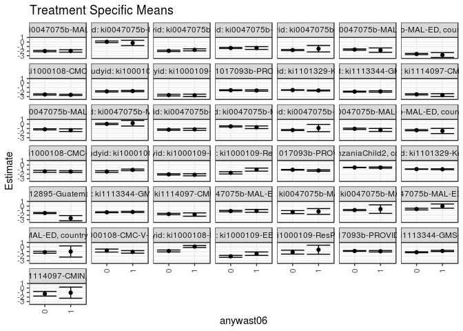

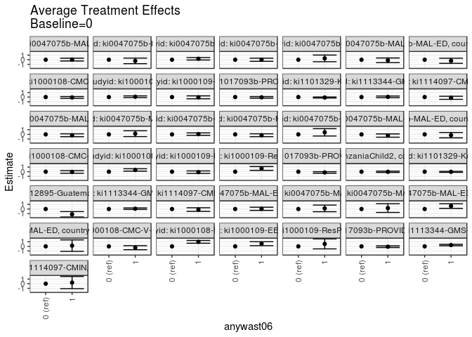

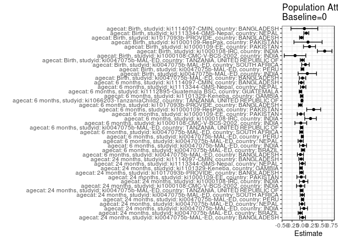

## Results Table

### Parameter: TSM

| agecat | studyid | country | intervention_level | baseline_level | estimate | ci_lower | ci_upper |
| --- | --- | --- | --- | --- | --- | --- | --- |
| Birth | ki0047075b-MAL-ED | BANGLADESH | 0 | NA | -1.1166345 | -1.2660859 | -0.9671831 |
| Birth | ki0047075b-MAL-ED | BANGLADESH | 1 | NA | -1.0667726 | -1.3782458 | -0.7552994 |
| Birth | ki0047075b-MAL-ED | INDIA | 0 | NA | -1.3352226 | -1.6660503 | -1.0043949 |
| Birth | ki0047075b-MAL-ED | INDIA | 1 | NA | -1.1945042 | -1.8235179 | -0.5654906 |
| Birth | ki0047075b-MAL-ED | PERU | 0 | NA | -0.8921788 | -1.0093401 | -0.7750176 |
| Birth | ki0047075b-MAL-ED | PERU | 1 | NA | -0.6797246 | -1.6228838 | 0.2634346 |
| Birth | ki0047075b-MAL-ED | SOUTH AFRICA | 0 | NA | -0.6724113 | -0.8566549 | -0.4881678 |
| Birth | ki0047075b-MAL-ED | SOUTH AFRICA | 1 | NA | -0.0224130 | -0.4894893 | 0.4446632 |
| Birth | ki0047075b-MAL-ED | TANZANIA, UNITED REPUBLIC OF | 0 | NA | -1.1432773 | -1.3541075 | -0.9324471 |
| Birth | ki0047075b-MAL-ED | TANZANIA, UNITED REPUBLIC OF | 1 | NA | -0.9860000 | -2.2167588 | 0.2447588 |
| Birth | ki1000108-CMC-V-BCS-2002 | INDIA | 0 | NA | -0.7868067 | -1.1184084 | -0.4552050 |
| Birth | ki1000108-CMC-V-BCS-2002 | INDIA | 1 | NA | -1.0786301 | -1.3614127 | -0.7958475 |
| Birth | ki1000108-IRC | INDIA | 0 | NA | -0.8736710 | -1.0840436 | -0.6632983 |
| Birth | ki1000108-IRC | INDIA | 1 | NA | 0.1075981 | -0.1089330 | 0.3241292 |
| Birth | ki1000109-EE | PAKISTAN | 0 | NA | -2.0477185 | -2.2586778 | -1.8367591 |
| Birth | ki1000109-EE | PAKISTAN | 1 | NA | -1.4670966 | -1.8420951 | -1.0920981 |
| Birth | ki1000109-ResPak | PAKISTAN | 0 | NA | -1.1296205 | -1.5586607 | -0.7005803 |
| Birth | ki1000109-ResPak | PAKISTAN | 1 | NA | -0.5912673 | -1.5808347 | 0.3983000 |
| Birth | ki1017093b-PROVIDE | BANGLADESH | 0 | NA | -0.8699836 | -0.9551364 | -0.7848309 |
| Birth | ki1017093b-PROVIDE | BANGLADESH | 1 | NA | -0.9409875 | -1.0966672 | -0.7853078 |
| Birth | ki1113344-GMS-Nepal | NEPAL | 0 | NA | -1.1525158 | -1.2529656 | -1.0520660 |
| Birth | ki1113344-GMS-Nepal | NEPAL | 1 | NA | -0.8672220 | -0.9896584 | -0.7447856 |
| Birth | ki1114097-CMIN | BANGLADESH | 0 | NA | -1.2613333 | -1.7710980 | -0.7515686 |
| Birth | ki1114097-CMIN | BANGLADESH | 1 | NA | -1.0280000 | -2.2553082 | 0.1993082 |
| 6 months | ki0047075b-MAL-ED | BANGLADESH | 0 | NA | -1.1662401 | -1.2907018 | -1.0417784 |
| 6 months | ki0047075b-MAL-ED | BANGLADESH | 1 | NA | -1.3567323 | -1.6469977 | -1.0664668 |
| 6 months | ki0047075b-MAL-ED | BRAZIL | 0 | NA | 0.0274268 | -0.1218470 | 0.1767007 |
| 6 months | ki0047075b-MAL-ED | BRAZIL | 1 | NA | 0.1797865 | -0.4374767 | 0.7970496 |
| 6 months | ki0047075b-MAL-ED | INDIA | 0 | NA | -1.2378414 | -1.3794547 | -1.0962280 |
| 6 months | ki0047075b-MAL-ED | INDIA | 1 | NA | -1.1774158 | -1.3973614 | -0.9574701 |

[output cut: 56 more lines]

### Parameter: E(Y)

| agecat | studyid | country | intervention_level | baseline_level | estimate | ci_lower | ci_upper |
| --- | --- | --- | --- | --- | --- | --- | --- |
| Birth | ki0047075b-MAL-ED | BANGLADESH | NA | NA | -1.1041048 | -1.2383048 | -0.9699048 |
| Birth | ki0047075b-MAL-ED | INDIA | NA | NA | -1.2036170 | -1.4976814 | -0.9095527 |
| Birth | ki0047075b-MAL-ED | PERU | NA | NA | -0.8827897 | -1.0001058 | -0.7654736 |
| Birth | ki0047075b-MAL-ED | SOUTH AFRICA | NA | NA | -0.5877869 | -0.7622273 | -0.4133464 |
| Birth | ki0047075b-MAL-ED | TANZANIA, UNITED REPUBLIC OF | NA | NA | -1.1369355 | -1.3453337 | -0.9285373 |
| Birth | ki1000108-CMC-V-BCS-2002 | INDIA | NA | NA | -0.9611957 | -1.1776967 | -0.7446946 |
| Birth | ki1000108-IRC | INDIA | NA | NA | -0.3080412 | -0.4687931 | -0.1472894 |
| Birth | ki1000109-EE | PAKISTAN | NA | NA | -1.8608750 | -2.0482045 | -1.6735455 |
| Birth | ki1000109-ResPak | PAKISTAN | NA | NA | -0.9800000 | -1.4086438 | -0.5513562 |
| Birth | ki1017093b-PROVIDE | BANGLADESH | NA | NA | -0.8851020 | -0.9601332 | -0.8100709 |
| Birth | ki1113344-GMS-Nepal | NEPAL | NA | NA | -1.0454532 | -1.1235003 | -0.9674062 |
| Birth | ki1114097-CMIN | BANGLADESH | NA | NA | -1.2030000 | -1.6953191 | -0.7106809 |
| 6 months | ki0047075b-MAL-ED | BANGLADESH | NA | NA | -1.2054910 | -1.3228953 | -1.0880867 |
| 6 months | ki0047075b-MAL-ED | BRAZIL | NA | NA | 0.0510207 | -0.0930194 | 0.1950608 |
| 6 months | ki0047075b-MAL-ED | INDIA | NA | NA | -1.2113701 | -1.3298485 | -1.0928916 |
| 6 months | ki0047075b-MAL-ED | NEPAL | NA | NA | -0.5610593 | -0.6737915 | -0.4483272 |
| 6 months | ki0047075b-MAL-ED | PERU | NA | NA | -1.3280952 | -1.4363364 | -1.2198541 |
| 6 months | ki0047075b-MAL-ED | SOUTH AFRICA | NA | NA | -1.0639173 | -1.1916078 | -0.9362269 |
| 6 months | ki0047075b-MAL-ED | TANZANIA, UNITED REPUBLIC OF | NA | NA | -1.3687449 | -1.4907629 | -1.2467270 |
| 6 months | ki1000108-CMC-V-BCS-2002 | INDIA | NA | NA | -1.4241872 | -1.5668135 | -1.2815609 |
| 6 months | ki1000108-IRC | INDIA | NA | NA | -1.2344062 | -1.3658524 | -1.1029600 |
| 6 months | ki1000109-EE | PAKISTAN | NA | NA | -2.0835567 | -2.2027557 | -1.9643578 |
| 6 months | ki1000109-ResPak | PAKISTAN | NA | NA | -1.4314086 | -1.6374838 | -1.2253335 |
| 6 months | ki1017093b-PROVIDE | BANGLADESH | NA | NA | -1.0916915 | -1.1661176 | -1.0172654 |
| 6 months | ki1066203-TanzaniaChild2 | TANZANIA, UNITED REPUBLIC OF | NA | NA | -0.5434389 | -0.5924056 | -0.4944722 |
| 6 months | ki1101329-Keneba | GAMBIA | NA | NA | -0.9116762 | -0.9588660 | -0.8644864 |
| 6 months | ki1112895-Guatemala BSC | GUATEMALA | NA | NA | -1.5785476 | -1.6926664 | -1.4644288 |
| 6 months | ki1113344-GMS-Nepal | NEPAL | NA | NA | -1.3508392 | -1.4290633 | -1.2726152 |
| 6 months | ki1114097-CMIN | BANGLADESH | NA | NA | -1.7844376 | -1.9222926 | -1.6465825 |
| 24 months | ki0047075b-MAL-ED | BANGLADESH | NA | NA | -1.9789151 | -2.1055330 | -1.8522972 |
| 24 months | ki0047075b-MAL-ED | BRAZIL | NA | NA | 0.0071006 | -0.1615817 | 0.1757828 |
| 24 months | ki0047075b-MAL-ED | INDIA | NA | NA | -1.8848458 | -2.0096941 | -1.7599975 |
| 24 months | ki0047075b-MAL-ED | NEPAL | NA | NA | -1.3118640 | -1.4315132 | -1.1922149 |
| 24 months | ki0047075b-MAL-ED | PERU | NA | NA | -1.7544776 | -1.8753255 | -1.6336298 |
| 24 months | ki0047075b-MAL-ED | SOUTH AFRICA | NA | NA | -1.6491807 | -1.7842885 | -1.5140729 |
| 24 months | ki0047075b-MAL-ED | TANZANIA, UNITED REPUBLIC OF | NA | NA | -2.6451636 | -2.7802323 | -2.5100948 |
| 24 months | ki1000108-CMC-V-BCS-2002 | INDIA | NA | NA | -2.5489071 | -2.6476125 | -2.4502017 |
| 24 months | ki1000108-IRC | INDIA | NA | NA | -1.7987775 | -1.8923914 | -1.7051636 |
| 24 months | ki1000109-EE | PAKISTAN | NA | NA | -2.6699900 | -2.8138051 | -2.5261749 |
| 24 months | ki1017093b-PROVIDE | BANGLADESH | NA | NA | -1.6024221 | -1.6857420 | -1.5191023 |
| 24 months | ki1101329-Keneba | GAMBIA | NA | NA | -1.5774758 | -1.6295950 | -1.5253566 |
| 24 months | ki1113344-GMS-Nepal | NEPAL | NA | NA | -1.8874180 | -1.9728588 | -1.8019773 |
| 24 months | ki1114097-CMIN | BANGLADESH | NA | NA | -2.5109504 | -2.6361514 | -2.3857494 |

### Parameter: ATE

| agecat | studyid | country | intervention_level | baseline_level | estimate | ci_lower | ci_upper |
| --- | --- | --- | --- | --- | --- | --- | --- |
| Birth | ki0047075b-MAL-ED | BANGLADESH | 0 | 0 | 0.0000000 | 0.0000000 | 0.0000000 |
| Birth | ki0047075b-MAL-ED | BANGLADESH | 1 | 0 | 0.0498619 | -0.2962435 | 0.3959673 |
| Birth | ki0047075b-MAL-ED | INDIA | 0 | 0 | 0.0000000 | 0.0000000 | 0.0000000 |
| Birth | ki0047075b-MAL-ED | INDIA | 1 | 0 | 0.1407183 | -0.5786417 | 0.8600784 |
| Birth | ki0047075b-MAL-ED | PERU | 0 | 0 | 0.0000000 | 0.0000000 | 0.0000000 |
| Birth | ki0047075b-MAL-ED | PERU | 1 | 0 | 0.2124543 | -0.7377458 | 1.1626544 |
| Birth | ki0047075b-MAL-ED | SOUTH AFRICA | 0 | 0 | 0.0000000 | 0.0000000 | 0.0000000 |
| Birth | ki0047075b-MAL-ED | SOUTH AFRICA | 1 | 0 | 0.6499983 | 0.1413472 | 1.1586494 |
| Birth | ki0047075b-MAL-ED | TANZANIA, UNITED REPUBLIC OF | 0 | 0 | 0.0000000 | 0.0000000 | 0.0000000 |
| Birth | ki0047075b-MAL-ED | TANZANIA, UNITED REPUBLIC OF | 1 | 0 | 0.1572773 | -1.0914086 | 1.4059632 |
| Birth | ki1000108-CMC-V-BCS-2002 | INDIA | 0 | 0 | 0.0000000 | 0.0000000 | 0.0000000 |
| Birth | ki1000108-CMC-V-BCS-2002 | INDIA | 1 | 0 | -0.2918234 | -0.7302687 | 0.1466219 |
| Birth | ki1000108-IRC | INDIA | 0 | 0 | 0.0000000 | 0.0000000 | 0.0000000 |
| Birth | ki1000108-IRC | INDIA | 1 | 0 | 0.9812691 | 0.6788780 | 1.2836601 |
| Birth | ki1000109-EE | PAKISTAN | 0 | 0 | 0.0000000 | 0.0000000 | 0.0000000 |
| Birth | ki1000109-EE | PAKISTAN | 1 | 0 | 0.5806219 | 0.1518484 | 1.0093954 |
| Birth | ki1000109-ResPak | PAKISTAN | 0 | 0 | 0.0000000 | 0.0000000 | 0.0000000 |
| Birth | ki1000109-ResPak | PAKISTAN | 1 | 0 | 0.5383532 | -0.5518423 | 1.6285487 |
| Birth | ki1017093b-PROVIDE | BANGLADESH | 0 | 0 | 0.0000000 | 0.0000000 | 0.0000000 |
| Birth | ki1017093b-PROVIDE | BANGLADESH | 1 | 0 | -0.0710039 | -0.2483967 | 0.1063890 |
| Birth | ki1113344-GMS-Nepal | NEPAL | 0 | 0 | 0.0000000 | 0.0000000 | 0.0000000 |
| Birth | ki1113344-GMS-Nepal | NEPAL | 1 | 0 | 0.2852938 | 0.1273476 | 0.4432401 |
| Birth | ki1114097-CMIN | BANGLADESH | 0 | 0 | 0.0000000 | 0.0000000 | 0.0000000 |
| Birth | ki1114097-CMIN | BANGLADESH | 1 | 0 | 0.2333333 | -1.0956307 | 1.5622974 |
| 6 months | ki0047075b-MAL-ED | BANGLADESH | 0 | 0 | 0.0000000 | 0.0000000 | 0.0000000 |
| 6 months | ki0047075b-MAL-ED | BANGLADESH | 1 | 0 | -0.1904922 | -0.5066934 | 0.1257091 |
| 6 months | ki0047075b-MAL-ED | BRAZIL | 0 | 0 | 0.0000000 | 0.0000000 | 0.0000000 |
| 6 months | ki0047075b-MAL-ED | BRAZIL | 1 | 0 | 0.1523597 | -0.4831023 | 0.7878216 |
| 6 months | ki0047075b-MAL-ED | INDIA | 0 | 0 | 0.0000000 | 0.0000000 | 0.0000000 |
| 6 months | ki0047075b-MAL-ED | INDIA | 1 | 0 | 0.0604256 | -0.2019004 | 0.3227516 |

[output cut: 56 more lines]

### Parameter: PAR

| agecat | studyid | country | intervention_level | baseline_level | estimate | ci_lower | ci_upper |
| --- | --- | --- | --- | --- | --- | --- | --- |
| Birth | ki0047075b-MAL-ED | BANGLADESH | 0 | NA | 0.0125297 | -0.0677542 | 0.0928137 |
| Birth | ki0047075b-MAL-ED | INDIA | 0 | NA | 0.1316055 | -0.0989078 | 0.3621189 |
| Birth | ki0047075b-MAL-ED | PERU | 0 | NA | 0.0093891 | -0.0255858 | 0.0443641 |
| Birth | ki0047075b-MAL-ED | SOUTH AFRICA | 0 | NA | 0.0846245 | -0.0091942 | 0.1784431 |
| Birth | ki0047075b-MAL-ED | TANZANIA, UNITED REPUBLIC OF | 0 | NA | 0.0063418 | -0.0443044 | 0.0569881 |
| Birth | ki1000108-CMC-V-BCS-2002 | INDIA | 0 | NA | -0.1743889 | -0.4431371 | 0.0943592 |
| Birth | ki1000108-IRC | INDIA | 0 | NA | 0.5656297 | 0.3843398 | 0.7469197 |
| Birth | ki1000109-EE | PAKISTAN | 0 | NA | 0.1868435 | 0.0366026 | 0.3370843 |
| Birth | ki1000109-ResPak | PAKISTAN | 0 | NA | 0.1496205 | -0.2022347 | 0.5014757 |
| Birth | ki1017093b-PROVIDE | BANGLADESH | 0 | NA | -0.0151184 | -0.0631507 | 0.0329139 |
| Birth | ki1113344-GMS-Nepal | NEPAL | 0 | NA | 0.1070626 | 0.0461884 | 0.1679367 |
| Birth | ki1114097-CMIN | BANGLADESH | 0 | NA | 0.0583333 | -0.2769994 | 0.3936660 |
| 6 months | ki0047075b-MAL-ED | BANGLADESH | 0 | NA | -0.0392509 | -0.1149061 | 0.0364042 |
| 6 months | ki0047075b-MAL-ED | BRAZIL | 0 | NA | 0.0235939 | -0.0186586 | 0.0658464 |
| 6 months | ki0047075b-MAL-ED | INDIA | 0 | NA | 0.0264713 | -0.0590710 | 0.1120135 |
| 6 months | ki0047075b-MAL-ED | NEPAL | 0 | NA | -0.0347562 | -0.0998087 | 0.0302964 |
| 6 months | ki0047075b-MAL-ED | PERU | 0 | NA | 0.0071933 | -0.0186176 | 0.0330041 |
| 6 months | ki0047075b-MAL-ED | SOUTH AFRICA | 0 | NA | -0.0174773 | -0.0594106 | 0.0244560 |
| 6 months | ki0047075b-MAL-ED | TANZANIA, UNITED REPUBLIC OF | 0 | NA | -0.0090982 | -0.0421999 | 0.0240035 |
| 6 months | ki1000108-CMC-V-BCS-2002 | INDIA | 0 | NA | -0.0313834 | -0.1776545 | 0.1148876 |
| 6 months | ki1000108-IRC | INDIA | 0 | NA | 0.2122506 | 0.0674316 | 0.3570696 |
| 6 months | ki1000109-EE | PAKISTAN | 0 | NA | -0.0318018 | -0.1201957 | 0.0565922 |
| 6 months | ki1000109-ResPak | PAKISTAN | 0 | NA | 0.2908385 | 0.1160442 | 0.4656327 |
| 6 months | ki1017093b-PROVIDE | BANGLADESH | 0 | NA | -0.0442436 | -0.0888264 | 0.0003392 |
| 6 months | ki1066203-TanzaniaChild2 | TANZANIA, UNITED REPUBLIC OF | 0 | NA | -0.0015156 | -0.0223523 | 0.0193211 |
| 6 months | ki1101329-Keneba | GAMBIA | 0 | NA | -0.0084872 | -0.0415723 | 0.0245980 |
| 6 months | ki1112895-Guatemala BSC | GUATEMALA | 0 | NA | -0.0386982 | -0.0703736 | -0.0070228 |
| 6 months | ki1113344-GMS-Nepal | NEPAL | 0 | NA | 0.0286823 | -0.0381545 | 0.0955192 |
| 6 months | ki1114097-CMIN | BANGLADESH | 0 | NA | -0.0188417 | -0.0840032 | 0.0463198 |
| 24 months | ki0047075b-MAL-ED | BANGLADESH | 0 | NA | 0.0140189 | -0.0570994 | 0.0851373 |
| 24 months | ki0047075b-MAL-ED | BRAZIL | 0 | NA | -0.0458407 | -0.0974990 | 0.0058177 |
| 24 months | ki0047075b-MAL-ED | INDIA | 0 | NA | 0.0472012 | -0.0432115 | 0.1376139 |
| 24 months | ki0047075b-MAL-ED | NEPAL | 0 | NA | -0.0010496 | -0.0670407 | 0.0649416 |
| 24 months | ki0047075b-MAL-ED | PERU | 0 | NA | 0.0117141 | -0.0181898 | 0.0416180 |
| 24 months | ki0047075b-MAL-ED | SOUTH AFRICA | 0 | NA | 0.0057406 | -0.0479346 | 0.0594157 |
| 24 months | ki0047075b-MAL-ED | TANZANIA, UNITED REPUBLIC OF | 0 | NA | -0.0114409 | -0.0486783 | 0.0257966 |
| 24 months | ki1000108-CMC-V-BCS-2002 | INDIA | 0 | NA | -0.0354735 | -0.1382378 | 0.0672908 |
| 24 months | ki1000108-IRC | INDIA | 0 | NA | 0.0411853 | -0.0630899 | 0.1454604 |
| 24 months | ki1000109-EE | PAKISTAN | 0 | NA | -0.0197268 | -0.1281641 | 0.0887106 |
| 24 months | ki1017093b-PROVIDE | BANGLADESH | 0 | NA | -0.0158138 | -0.0605296 | 0.0289021 |
| 24 months | ki1101329-Keneba | GAMBIA | 0 | NA | -0.0274913 | -0.0627149 | 0.0077324 |
| 24 months | ki1113344-GMS-Nepal | NEPAL | 0 | NA | 0.0071770 | -0.0623434 | 0.0766975 |
| 24 months | ki1114097-CMIN | BANGLADESH | 0 | NA | -0.0221854 | -0.0792040 | 0.0348331 |